# Write_Up

Alexander B. Pastora

November 29, 2016

```r
# Load necessary packages
set.seed(76)
library(tidyverse)
library(jsonlite)
library(RCurl)
library(rvest)
library(forcats)
library(stringr)
```

## Abstract

This study looked at star ratings of restaurants in Charlotte, Las Vegas, Madison, Phoenix, Pittsburgh and Urbana_Champaing. Specifically, this data was used to create a model that attempts determine if a Good Star Rating (greater than 3 out of 5) could be determined from certain attributes of a restaurant. In addition to these attributes, demographic and income data were incorporated into the model. Although a model was created for the restaurant data, the model was only accurate about 63% of the time. This suggests that predicting a restaurant’s rating by attributes and location is not an accurate method. This may suggest that, for the restaurant data, other factors such as the quality and taste of the food may be more important.

## Introduction

Yelp is a website where people can look up businesses, view information and certain attributes associated with these businesses, and review the businesses. One specific aspect of Yelp is that it assigns each of these businesses a star rating out of 5 based on all of the reviews that have been created about the business. The main goal of this project is to determine if these star ratings are “genuine” or if they can be predicted by certain attributes associated with the business, as well as demographic and income information based on the location of the business. Specifically, this project will focus on predicting a star rating for restaurants, since one would expect that a restaurant’s star rating would depend almost exculsively on food taste and quality.

## Data Unpacking and Clean Up

The data about the Restaurants on Yelp was taken from the Yelp Dataset Challenge. Since these data were prepared specifically by Yelp, the dataset only includes business in Edinburgh(Scotland), Karlsruhe(Germany), Montreal(Canada), Waterloo (Canada), Charlotte, Las Vegas, Phoenix, Pittsburg, Madison, and Urbana-Champaign. Since the dataset was specifically prepared for a Challege, it does not necessary encompass all of the businesses/restaurants in these areas.

This dataset came in the form of a TAR File, which is very similar to a ZIP File, meaning that the TAR File actually contains multiple files within it. Once unpacked, the dataset was presented in the form of 5 JSON files. I then converted these JSON files into data tables that could be used in RStudio. The specfic method that I used was developed by Kan Nishida.

Since demographic and income data will be incorporated into the model, this particular project only focused on restaurants in the United States. In order to get demographic and income data about each of the restaurants, it was necessary to first get the FIPS codes for all of the restaurants. This was done through utilization of the FCC’s Census Block Conversion API, which takes a Longitude and Latitude, and returns the associated FIPS Code. In order to do this, a function had to be created that grabbed the lattitude and longitude of each restaurant, combined it into a generalized URL format, pulled the data from this specific Url associated with the restaurants location, and extracted the FIPS Code associated with the restaurant. My specific function was modified from a function by John Ramey.

```r
# First, unpack the files contained in the tar file.
untar("yelp_dataset_challenge_academic_dataset.tar")

yelp_business <- stream_in(file("yelp_academic_dataset_business.json"))
yelp_business_flat <- flatten(yelp_business)
yelp_business_flat <- yelp_business_flat %>% mutate(categories = as.character(categories))

yelp_checkin <- stream_in(file("yelp_academic_dataset_checkin.json"))
yelp_checkin_flat <- flatten(yelp_checkin)

yelp_review <- stream_in(file("yelp_academic_dataset_review.json"))
yelp_review_flat <-flatten(yelp_review)

yelp_tip <- stream_in(file("yelp_academic_dataset_tip.json"))
yelp_tip_flat <-flatten(yelp_tip)

yelp_user <- stream_in(file("yelp_academic_dataset_user.json"))
yelp_user_flat <-flatten(yelp_user)

# Get US State Abbreviations
states <-tbl_df(state.abb)

# Only Use US Data
yelp_business_US <- semi_join(yelp_business_flat, states, by=c("state"= "value"))

# Only Use Restaurants
yelp_US_restaurants <- yelp_business_US %>% filter(str_detect(categories,c("Food","Restaurants")))
# Lattitude and Longitude to FIPS

latlong2fips <- function(latitude, longitude) {
  url <- (paste0("http://data.fcc.gov/api/block/find?format=json&latitude=",as.character(latitude),"&longitude=",as.character(longitude),"&showall=false"))
        data <- fromJSON(RCurl::getURL(url))
        as.character(data$Block[1])}
```

## Get FIPS Codes

In order to get the FIPS Codes from the API, I first chopped up the dataset by states, and then further chopped up the states so that each piece had about 1000. The purpose of choppin up the dataset is to improve the response time from the API. By chopping up the data into pieces, the response time was about 10 minutes per piece. After all of the FIPS codes were obtained and added to the restaurants, all of the pieces were recombined to reform the original dataset.

Since the whole process of getting the FIPS codes took so much time, I exported the dataset into a csv file so that the FIPS codes do not have to be taken from the API again, and to shorten the runtime of this Markdown File. This specific csv file, however, only included the columns of the dataset that were relevant to the Exploratory Data Analysis Performed later in this write-up.

```r
yelp_US_restaurants <- yelp_business_US %>% filter(str_detect(categories,c("Food","Restaurants")))

# Break Up the chunks, so that I can get FIPS Codes faster
yelp_AZ_restaurants <- yelp_US_restaurants %>% filter(state =="AZ")
yelp_AZ_restaurants1 <- yelp_AZ_restaurants %>% sample_n(1000)
yelp_AZ_restaurants_ref <- anti_join(yelp_AZ_restaurants,yelp_AZ_restaurants1, by="business_id")
yelp_AZ_restaurants2 <- yelp_AZ_restaurants_ref %>% sample_n(1000)
yelp_AZ_restaurants_ref <- anti_join(yelp_AZ_restaurants_ref,yelp_AZ_restaurants2, by="business_id")
yelp_AZ_restaurants3 <- yelp_AZ_restaurants_ref %>% sample_n(1000)
yelp_AZ_restaurants_ref <- anti_join(yelp_AZ_restaurants_ref,yelp_AZ_restaurants3, by="business_id")
yelp_AZ_restaurants4 <- yelp_AZ_restaurants_ref %>% sample_n(1000)
yelp_AZ_restaurants_ref <- anti_join(yelp_AZ_restaurants_ref,yelp_AZ_restaurants4, by="business_id")
yelp_AZ_restaurants5 <- yelp_AZ_restaurants_ref %>% sample_n(1000)
yelp_AZ_restaurants_ref <- anti_join(yelp_AZ_restaurants_ref,yelp_AZ_restaurants5, by="business_id")
yelp_AZ_restaurants6 <- yelp_AZ_restaurants_ref %>% sample_n(1000)
yelp_AZ_restaurants_ref <- anti_join(yelp_AZ_restaurants_ref,yelp_AZ_restaurants6, by="business_id")
yelp_AZ_restaurants7 <- yelp_AZ_restaurants_ref %>% sample_n(1000)
yelp_AZ_restaurants_ref <- anti_join(yelp_AZ_restaurants_ref,yelp_AZ_restaurants7, by="business_id")
yelp_AZ_restaurants8 <- yelp_AZ_restaurants_ref

#Get FIPS Codes
yelp_AZ_restaurants1 <- yelp_AZ_restaurants1 %>% rowwise() %>% mutate(FIPS = latlong2fips(latitude, longitude))
yelp_AZ_restaurants2 <- yelp_AZ_restaurants2 %>% rowwise() %>% mutate(FIPS = latlong2fips(latitude, longitude))
yelp_AZ_restaurants3 <- yelp_AZ_restaurants3 %>% rowwise() %>% mutate(FIPS = latlong2fips(latitude, longitude))
yelp_AZ_restaurants4 <- yelp_AZ_restaurants4 %>% rowwise() %>% mutate(FIPS = latlong2fips(latitude, longitude))
yelp_AZ_restaurants5 <- yelp_AZ_restaurants5 %>% rowwise() %>% mutate(FIPS = latlong2fips(latitude, longitude))
yelp_AZ_restaurants6 <- yelp_AZ_restaurants6 %>% rowwise() %>% mutate(FIPS = latlong2fips(latitude, longitude))
yelp_AZ_restaurants7 <- yelp_AZ_restaurants7 %>% rowwise() %>% mutate(FIPS = latlong2fips(latitude, longitude))
yelp_AZ_restaurants8 <- yelp_AZ_restaurants8 %>% rowwise() %>% mutate(FIPS = latlong2fips(latitude, longitude))

# Recombine
yelp_AZ_restaurants_ref <- bind_rows(yelp_AZ_restaurants1,yelp_AZ_restaurants2)
yelp_AZ_restaurants_ref <- bind_rows(yelp_AZ_restaurants_ref, yelp_AZ_restaurants3)
yelp_AZ_restaurants_ref <- bind_rows(yelp_AZ_restaurants_ref, yelp_AZ_restaurants4)
yelp_AZ_restaurants_ref <- bind_rows(yelp_AZ_restaurants_ref, yelp_AZ_restaurants5)
yelp_AZ_restaurants_ref <- bind_rows(yelp_AZ_restaurants_ref, yelp_AZ_restaurants6)
yelp_AZ_restaurants_ref <- bind_rows(yelp_AZ_restaurants_ref, yelp_AZ_restaurants7)
yelp_AZ_restaurants_ref <- bind_rows(yelp_AZ_restaurants_ref, yelp_AZ_restaurants8)
yelp_AZ_restaurants <- yelp_AZ_restaurants_ref

# Done
yelp_IL_restaurants <- yelp_US_restaurants %>% filter(state =="IL")
yelp_IL_restaurants <- yelp_IL_restaurants %>% rowwise() %>% mutate(FIPS = latlong2fips(latitude, longitude))

# Break Dataset into piece, so that FCC API doesn't have to work as hard, and the response time is faster.
# Done
yelp_NC_restaurants <- yelp_US_restaurants %>% filter(state =="NC")
yelp_NC_restaurants1 <- yelp_NC_restaurants %>% sample_n(1000)
yelp_NC_restaurants2 <- anti_join(yelp_NC_restaurants,yelp_NC_restaurants1, by="business_id")
yelp_NC_restaurants1 <- yelp_NC_restaurants1 %>% rowwise() %>% mutate(FIPS = latlong2fips(latitude, longitude))
yelp_NC_restaurants2 <- yelp_NC_restaurants2 %>% rowwise() %>% mutate(FIPS = latlong2fips(latitude, longitude))
yelp_NC_restaurants <- bind_rows(yelp_NC_restaurants1,yelp_NC_restaurants2)


# Split the data
yelp_NV_restaurants <- yelp_US_restaurants %>% filter(state =="NV")
yelp_NV_restaurants1 <- yelp_NV_restaurants %>% sample_n(1000)
yelp_NV_restaurants_ref <- anti_join(yelp_NV_restaurants,yelp_NV_restaurants1, by="business_id")
yelp_NV_restaurants2 <- yelp_NV_restaurants_ref %>% sample_n(1000)
yelp_NV_restaurants_ref <- anti_join(yelp_NV_restaurants_ref,yelp_NV_restaurants2, by="business_id")
yelp_NV_restaurants3 <- yelp_NV_restaurants_ref %>% sample_n(1000)
yelp_NV_restaurants_ref <- anti_join(yelp_NV_restaurants_ref,yelp_NV_restaurants3, by="business_id")
yelp_NV_restaurants4 <- yelp_NV_restaurants_ref %>% sample_n(1000)
yelp_NV_restaurants_ref <- anti_join(yelp_NV_restaurants_ref,yelp_NV_restaurants4, by="business_id")
yelp_NV_restaurants5 <- yelp_NV_restaurants_ref

#Get FIPS Codes
yelp_NV_restaurants1 <- yelp_NV_restaurants1 %>% rowwise() %>% mutate(FIPS = latlong2fips(latitude, longitude))
yelp_NV_restaurants2 <- yelp_NV_restaurants2 %>% rowwise() %>% mutate(FIPS = latlong2fips(latitude, longitude))
yelp_NV_restaurants3 <- yelp_NV_restaurants3 %>% rowwise() %>% mutate(FIPS = latlong2fips(latitude, longitude))
yelp_NV_restaurants4 <- yelp_NV_restaurants4 %>% rowwise() %>% mutate(FIPS = latlong2fips(latitude, longitude))
yelp_NV_restaurants5 <- yelp_NV_restaurants5 %>% rowwise() %>% mutate(FIPS = latlong2fips(latitude, longitude))
# Recombine
yelp_NV_restaurants_ref <- bind_rows(yelp_NV_restaurants1,yelp_NV_restaurants2)
yelp_NV_restaurants_ref <- bind_rows(yelp_NV_restaurants_ref, yelp_NV_restaurants3)
yelp_NV_restaurants_ref <- bind_rows(yelp_NV_restaurants_ref,yelp_NV_restaurants4)
yelp_NV_restaurants_ref <- bind_rows(yelp_NV_restaurants_ref, yelp_NV_restaurants5)
yelp_NV_restaurants <- yelp_NV_restaurants_ref

# Done
yelp_PA_restaurants <- yelp_US_restaurants %>% filter(state=="PA")
yelp_PA_restaurants <- yelp_PA_restaurants %>% rowwise() %>% mutate(FIPS = latlong2fips(latitude,longitude))

# Done
yelp_WI_restaurants <- yelp_US_restaurants %>% filter(state=="WI")
yelp_WI_restaurants <- yelp_WI_restaurants %>% rowwise() %>% mutate(FIPS = latlong2fips(latitude,longitude))

# Recombine Everything
yelp_US_restaurants_ref <- bind_rows(yelp_AZ_restaurants,yelp_IL_restaurants)
yelp_US_restaurants_ref <- bind_rows(yelp_US_restaurants_ref, yelp_NC_restaurants)
yelp_US_restaurants_ref <- bind_rows(yelp_US_restaurants_ref, yelp_NV_restaurants)
yelp_US_restaurants_ref <- bind_rows(yelp_US_restaurants_ref, yelp_PA_restaurants)
yelp_US_restaurants_ref <- bind_rows(yelp_US_restaurants_ref, yelp_WI_restaurants)
yelp_US_restaurants <- yelp_US_restaurants_ref

yelp_US_restaurants_csv<- yelp_US_restaurants %>%
  select(FIPS,business_id,full_address,open,categories,city,review_count,name,longitude,state,stars,latitude,type,`attributes.Price Range`,attributes.Attire,`attributes.Take-out`,`attributes.Noise Level`,attributes.Alcohol,`attributes.Accepts Credit Cards`,`attributes.Wi-Fi`,`attributes.Good For.latenight`,attributes.Ambience.romantic,attributes.Ambience.intimate,attributes.Ambience.classy, attributes.Ambience.touristy, attributes.Parking.valet, attributes.Parking.validated, attributes.Parking.street,attributes.Music.background_music, `attributes.Dietary Restrictions.vegetarian`)
write_csv(yelp_US_restaurants_csv,path="yelp_US_restaurants.csv")
```

## Load the Demographic Data, Fix FIPS Codes, And Combine Datasets

The Demographic Data used in this experiment was taken from Social Explorer, and is specifically from the 2010 US Census. In order to speed up the response time of Social Explorer, the Demographic Data was exported as 6 different CSV files, seperated by the 6 different cities in the Yelp Data Set. Since this was the case, the Yelp Dataset was again split into six pieces based on the state. The relevant Demographic Data was appended to each restaurant based on the associated FIPS codes. All of the pieces were then recombined to reform the original dataset.

```r
yelp_US_restaurants <- read_csv("yelp_US_restaurants.csv")

# Load US Demographic Data
Charlotte_Demographic <-read.csv("Charlotte_Demographic.csv")
Las_Vegas_Demographic <-read.csv("Las_Vegas_Demographic.csv")
Madison_Demographic <-read.csv("Madison_Demographic.csv")
Phoenix_Demographic <-read.csv("Phoenix_Demographic.csv")
Pittsburgh_Demographic <-read.csv("Pittsburgh_Demographic.csv")
Urbana_Champaign_Demographic <-read.csv("Urbana_Champaign_Demographic.csv")

#Fix FIPS Codes
Charlotte_Demographic <- Charlotte_Demographic %>%
  mutate(Geo_FIPS= as.character(Geo_FIPS))

Las_Vegas_Demographic <- Las_Vegas_Demographic %>%
  mutate(Geo_FIPS= as.character(Geo_FIPS))

Madison_Demographic <- Madison_Demographic %>%
  mutate(Geo_FIPS= as.character(Geo_FIPS))

Phoenix_Demographic <- Phoenix_Demographic %>%
  mutate(Geo_FIPS= str_pad(as.character(Geo_FIPS),11, pad="0"))

Pittsburgh_Demographic <- Pittsburgh_Demographic %>%
  mutate(Geo_FIPS= as.character(Geo_FIPS))

Urbana_Champaign_Demographic <- Urbana_Champaign_Demographic %>%
  mutate(Geo_FIPS= as.character(Geo_FIPS))

# Shorten FIPS Codes in Other Set
yelp_AZ_restaurants_ref <- yelp_US_restaurants %>%
  filter(state=="AZ") %>%
  mutate(FIPS = str_sub(FIPS, 1,11))
yelp_IL_restaurants_ref <- yelp_US_restaurants %>%
  filter(state=="IL") %>%
  mutate(FIPS= str_sub(FIPS, 1, 12))
yelp_NC_restaurants_ref <- yelp_US_restaurants %>%
  filter(state=="NC") %>%
  mutate(FIPS= str_sub(FIPS, 1, 11))
yelp_NV_restaurants_ref <- yelp_US_restaurants %>%
  filter(state=="NV") %>%
  mutate(FIPS= str_sub(FIPS, 1, 11))
yelp_PA_restaurants_ref <- yelp_US_restaurants %>%
  filter(state=="PA") %>%
  mutate(FIPS= str_sub(FIPS, 1, 12))
yelp_WI_restaurants_ref <- yelp_US_restaurants %>%
  filter(state=="WI") %>%
  mutate(FIPS= str_sub(FIPS, 1, 11))

# Choose certain variables to utilize
Charlotte_Demographic_copy <- Charlotte_Demographic %>%
  select(Geo_FIPS,SE_T008_001,SE_T008_006,SE_T008_007, SE_T044_001, SE_T044_002, SE_T044_003, SE_T054_001, SE_T054_002,SE_T054_003,SE_T054_004,SE_T054_005,SE_T054_006,SE_T054_007,SE_T054_008)

Las_Vegas_Demographic_copy <- Las_Vegas_Demographic %>%
  select(Geo_FIPS,SE_T008_001,SE_T008_006,SE_T008_007, SE_T044_001, SE_T044_002, SE_T044_003, SE_T054_001, SE_T054_002,SE_T054_003,SE_T054_004,SE_T054_005,SE_T054_006,SE_T054_007,SE_T054_008)

Madison_Demographic_copy <- Madison_Demographic %>%
  select(Geo_FIPS,SE_T008_001,SE_T008_006,SE_T008_007, SE_T044_001, SE_T044_002, SE_T044_003, SE_T054_001, SE_T054_002,SE_T054_003,SE_T054_004,SE_T054_005,SE_T054_006,SE_T054_007,SE_T054_008)

Phoenix_Demographic_copy <- Phoenix_Demographic %>%
  select(Geo_FIPS,SE_T008_001,SE_T008_006,SE_T008_007, SE_T044_001, SE_T044_002, SE_T044_003, SE_T054_001, SE_T054_002,SE_T054_003,SE_T054_004,SE_T054_005,SE_T054_006,SE_T054_007,SE_T054_008)

Pittsburgh_Demographic_copy <- Pittsburgh_Demographic %>%
  select(Geo_FIPS,SE_T008_001,SE_T008_006,SE_T008_007, SE_T044_001, SE_T044_002, SE_T044_003, SE_T054_001, SE_T054_002,SE_T054_003,SE_T054_004,SE_T054_005,SE_T054_006,SE_T054_007,SE_T054_008)

Urbana_Champaign_Demographic_copy <- Urbana_Champaign_Demographic %>%
  select(Geo_FIPS,SE_T008_001,SE_T008_006,SE_T008_007, SE_T044_001, SE_T044_002, SE_T044_003, SE_T054_001, SE_T054_002,SE_T054_003,SE_T054_004,SE_T054_005,SE_T054_006,SE_T054_007,SE_T054_008)

# Rename Variables
Charlotte_Demographic_copy <- Charlotte_Demographic_copy %>%
  mutate(Proportion_18_to_24 = (SE_T008_006/SE_T008_001)) %>%
  mutate(Proportion_25_to_34 = (SE_T008_007/SE_T008_001)) %>%
  mutate(Average_Age = (SE_T044_001)) %>%
  mutate(Proportion_White = (SE_T054_002/SE_T054_001)) %>%
  mutate(Proportion_Black = (SE_T054_003/SE_T054_001))

Las_Vegas_Demographic_copy <- Las_Vegas_Demographic_copy %>%
  mutate(Proportion_18_to_24 = (SE_T008_006/SE_T008_001)) %>%
  mutate(Proportion_25_to_34 = (SE_T008_007/SE_T008_001)) %>%
  mutate(Average_Age = (SE_T044_001)) %>%
  mutate(Proportion_White = (SE_T054_002/SE_T054_001)) %>%
  mutate(Proportion_Black = (SE_T054_003/SE_T054_001))

Madison_Demographic_copy <- Madison_Demographic_copy %>%
  mutate(Proportion_18_to_24 = (SE_T008_006/SE_T008_001)) %>%
  mutate(Proportion_25_to_34 = (SE_T008_007/SE_T008_001)) %>%
  mutate(Average_Age = (SE_T044_001)) %>%
  mutate(Proportion_White = (SE_T054_002/SE_T054_001)) %>%
  mutate(Proportion_Black = (SE_T054_003/SE_T054_001))

Phoenix_Demographic_copy <- Phoenix_Demographic_copy %>%
  mutate(Proportion_18_to_24 = (SE_T008_006/SE_T008_001)) %>%
  mutate(Proportion_25_to_34 = (SE_T008_007/SE_T008_001)) %>%
  mutate(Average_Age = (SE_T044_001)) %>%
  mutate(Proportion_White = (SE_T054_002/SE_T054_001)) %>%
  mutate(Proportion_Black = (SE_T054_003/SE_T054_001))

Pittsburgh_Demographic_copy <- Pittsburgh_Demographic_copy %>%
  mutate(Proportion_18_to_24 = (SE_T008_006/SE_T008_001)) %>%
  mutate(Proportion_25_to_34 = (SE_T008_007/SE_T008_001)) %>%
  mutate(Average_Age = (SE_T044_001)) %>%
  mutate(Proportion_White = (SE_T054_002/SE_T054_001)) %>%
  mutate(Proportion_Black = (SE_T054_003/SE_T054_001))

Urbana_Champaign_Demographic_copy <- Urbana_Champaign_Demographic_copy %>%
  mutate(Proportion_18_to_24 = (SE_T008_006/SE_T008_001)) %>%
  mutate(Proportion_25_to_34 = (SE_T008_007/SE_T008_001)) %>%
  mutate(Average_Age = (SE_T044_001)) %>%
  mutate(Proportion_White = (SE_T054_002/SE_T054_001)) %>%
  mutate(Proportion_Black = (SE_T054_003/SE_T054_001))

# Combing Demographic Data
#Done
yelp_AZ_restaurants_ref2 <- left_join(yelp_AZ_restaurants_ref, Phoenix_Demographic_copy, by=c("FIPS"="Geo_FIPS"))

#Done
yelp_IL_restaurants_ref <- left_join(yelp_IL_restaurants_ref, Urbana_Champaign_Demographic_copy, by=c("FIPS"="Geo_FIPS"))
#Done
yelp_NC_restaurants_ref <- left_join(yelp_NC_restaurants_ref, Charlotte_Demographic_copy, by=c("FIPS"="Geo_FIPS"))
#Done
yelp_NV_restaurants_ref <- left_join(yelp_NV_restaurants_ref, Las_Vegas_Demographic_copy, by=c("FIPS"="Geo_FIPS"))
#Done
yelp_PA_restaurants_ref <- left_join(yelp_PA_restaurants_ref, Pittsburgh_Demographic_copy, by=c("FIPS"="Geo_FIPS"))
#Done
yelp_WI_restaurants_ref <- left_join(yelp_WI_restaurants_ref, Madison_Demographic_copy, by=c("FIPS"="Geo_FIPS"))
```

## Load the Income Data, Fix FIPS Codes, And Combine Datasets

The Income Data used in this experiment was taken from Social Explorer, and is specifically from the 2010 ACS Report. In order to speed up the response time of Social Explorer, the Income Data was exported as 6 different CSV files, seperated by the 6 different cities in the Yelp Data Set. Since this was the case, the Yelp Dataset was again split into six pieces based on the state. The relevant Income Data was appended to each restaurant based on the associated FIPS codes. All of the pieces were then recombined to reform the original dataset.

```r
# Load US Income Data
Charlotte_Income <-read.csv("Charlotte_Income.csv") %>%
   mutate(Median_Income = SE_T057_001) %>% select(Geo_FIPS, Median_Income)
Las_Vegas_Income <-read.csv("Las_Vegas_Income.csv") %>%
   mutate(Median_Income = SE_T057_001) %>% select(Geo_FIPS, Median_Income)
Madison_Income <-read.csv("Madison_Income.csv") %>%
   mutate(Median_Income = SE_T057_001) %>% select(Geo_FIPS, Median_Income)
Pittsburgh_Income <-read.csv("Pittsburgh_Income.csv") %>%
   mutate(Median_Income = SE_T057_001) %>% select(Geo_FIPS, Median_Income)
Phoenix_Income <-read.csv("Phoenix_Income.csv") %>%
   mutate(Median_Income = SE_T057_001) %>% select(Geo_FIPS, Median_Income)
Urbana_Champaign_Income <-read.csv("Urbana_Champaign_Income.csv") %>%
   mutate(Median_Income = SE_T057_001) %>% select(Geo_FIPS, Median_Income)



# Fix FIPS Codes
Charlotte_Income <- Charlotte_Income %>%
  mutate(Geo_FIPS= as.character(Geo_FIPS))
Las_Vegas_Income <- Las_Vegas_Income %>%
  mutate(Geo_FIPS= as.character(Geo_FIPS))
Madison_Income <- Madison_Income %>%
  mutate(Geo_FIPS= as.character(Geo_FIPS))
Pittsburgh_Income <- Pittsburgh_Income %>%
  mutate(Geo_FIPS= as.character(Geo_FIPS))
Phoenix_Income <- Phoenix_Income %>%
  mutate(Geo_FIPS= str_pad(as.character(Geo_FIPS),11, pad="0"))
Urbana_Champaign_Income <- Urbana_Champaign_Income %>%
  mutate(Geo_FIPS= as.character(Geo_FIPS))

# Combine Dataset
yelp_AZ_restaurants_ref2 <- left_join(yelp_AZ_restaurants_ref2, Phoenix_Income, by=c("FIPS"="Geo_FIPS"))

# Fix FIPS Again
yelp_IL_restaurants_ref <- yelp_IL_restaurants_ref %>%
  mutate(FIPS= str_sub(FIPS, 1, 11))
yelp_IL_restaurants_ref <- left_join(yelp_IL_restaurants_ref, Urbana_Champaign_Income, by=c("FIPS"="Geo_FIPS"))
yelp_NC_restaurants_ref <- left_join(yelp_NC_restaurants_ref, Charlotte_Income, by=c("FIPS"="Geo_FIPS"))
yelp_NV_restaurants_ref <- left_join(yelp_NV_restaurants_ref, Las_Vegas_Income, by=c("FIPS"="Geo_FIPS"))
yelp_PA_restaurants_ref <- left_join(yelp_PA_restaurants_ref, Pittsburgh_Income, by=c("FIPS"="Geo_FIPS"))
yelp_WI_restaurants_ref <- left_join(yelp_WI_restaurants_ref, Madison_Income, by=c("FIPS"="Geo_FIPS"))

yelp_US_restaurants_ref2 <- bind_rows(yelp_AZ_restaurants_ref2,yelp_IL_restaurants_ref)
yelp_US_restaurants_ref2 <- bind_rows(yelp_US_restaurants_ref2,yelp_NC_restaurants_ref)
yelp_US_restaurants_ref2 <- bind_rows(yelp_US_restaurants_ref2,yelp_NV_restaurants_ref)
yelp_US_restaurants_ref2 <- bind_rows(yelp_US_restaurants_ref2,yelp_PA_restaurants_ref)
yelp_US_restaurants_ref2 <- bind_rows(yelp_US_restaurants_ref2,yelp_WI_restaurants_ref)
```

## Exploratory Data Analysis

I specifically looked at Price Range, Attire, Take-Out, Noise Level, Alcohol, if the restaurant accepts credit cards,Wi-Fi, if the restaurant is open latenight, if it has a romantic atmosphere, if it has an intimate atmosphere, if it has a classy atmosphere, if it has a touristy atmosphere, if it has street parking, if it has validated parking, if it has valet parking, if it has a DJ, and if it has Vegetarian food. I also looked at the Median Income, Median Age, the proportion of white people, the proportion of black people, the proportion of people from age 18-24, and the proportion of people from age 25-34 of the restaurant.

Although all of these attributes were explored, the ones that I decided to use were Proportion of White People where the restaurant is located, the Median Income where the restaurant is located, the Price Range of the restaurant (out of 4), and if the restaurant accepts credit cards.

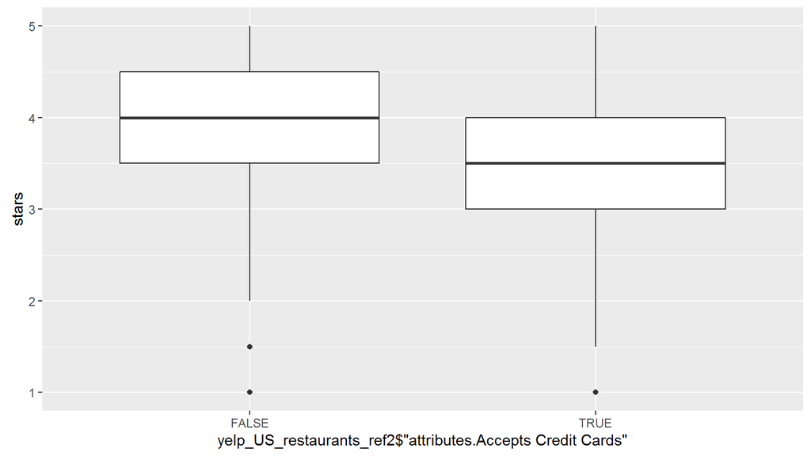

```r
# Stars vs. Accepts Credit Cards
ggplot(data=yelp_US_restaurants_ref2, aes(x=yelp_US_restaurants_ref2$'attributes.Accepts Credit Cards', y=stars, group=yelp_US_restaurants_ref2$'attributes.Accepts Credit Cards')) +geom_boxplot()
```

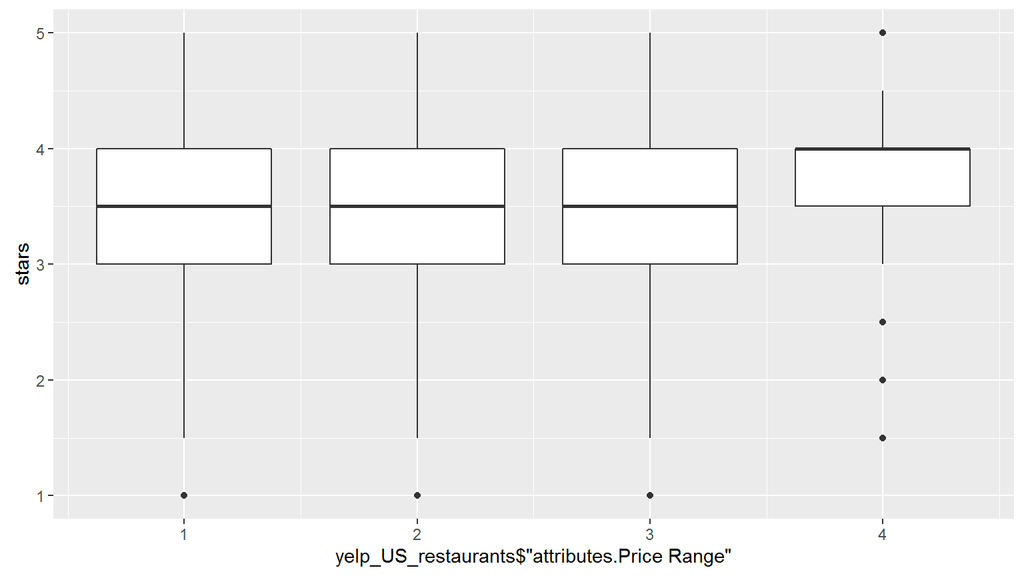

```r
# Stars vs. Price Range
ggplot(data=yelp_US_restaurants, aes(x=yelp_US_restaurants$'attributes.Price Range', y=stars, group=yelp_US_restaurants$'attributes.Price Range')) +geom_boxplot()
```

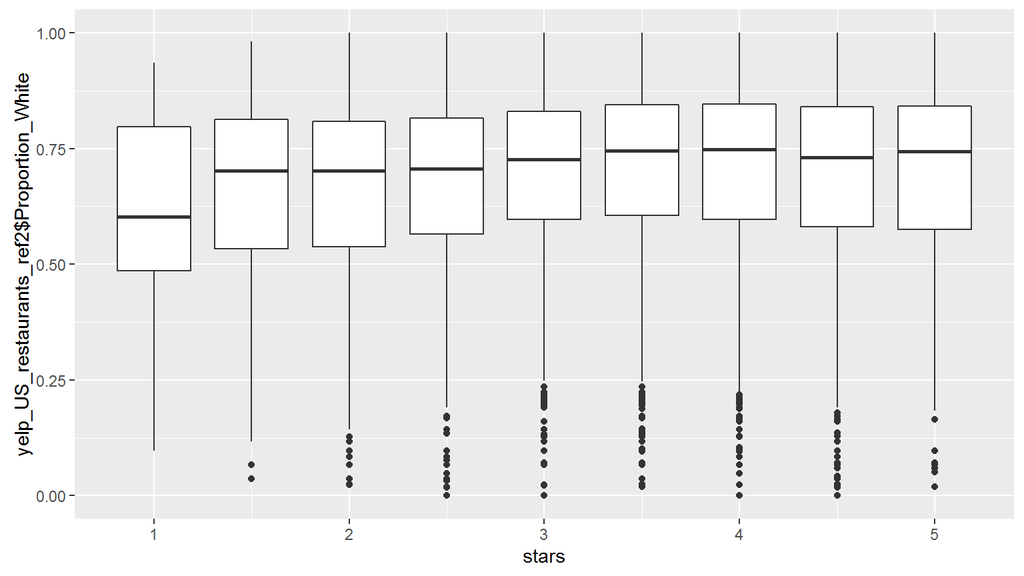

```r
# Stars vs. Proportion of White People
ggplot(data=yelp_US_restaurants_ref2, aes(y=yelp_US_restaurants_ref2$Proportion_White, x=stars, group=stars)) +geom_boxplot()
```

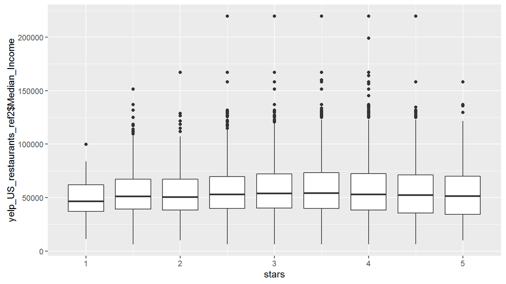

```r
# Stars vs. Median Income
ggplot(data=yelp_US_restaurants_ref2, aes(y=yelp_US_restaurants_ref2$Median_Income, x=stars, group=stars)) +geom_boxplot()
```

## Making a Model

In order to predict the rating of the restaurants, I created a logistic regression model using the four variables that I identified in the Exploratory Data Analysis. I defined a training set (5% of the restaurants.) in order to train the model to predict a good rating . Since I used this model, I defined a “good” rating as a star rating that was higher than three. I then tested the model on a test set (95% of the restaurants). The training set had a 66% success rate, and the test set had a 63% success set.

```r
# Take Care of all of the NA Values
yelp_US_restaurants_ref2 <- yelp_US_restaurants_ref2 %>%
    mutate(is_good_rating=ifelse(stars>3, 1, 0))
yelp_US_restaurants_ref2 <- yelp_US_restaurants_ref2 %>%
  filter(!is.na(Proportion_White))
yelp_US_restaurants_ref2 <- yelp_US_restaurants_ref2 %>%
  filter(!is.na(Median_Income))
yelp_US_restaurants_ref2 <- yelp_US_restaurants_ref2 %>%
  filter(!is.na(`attributes.Accepts Credit Cards`))
yelp_US_restaurants_ref2 <- yelp_US_restaurants_ref2 %>%
  filter(!is.na(`attributes.Price Range`))

# Training the model
training <- yelp_US_restaurants_ref2 %>% sample_n(685)
test <- anti_join(yelp_US_restaurants_ref2, training, by="business_id")

predict_good_rating_model <- glm(is_good_rating ~ Proportion_White + Median_Income + `attributes.Accepts Credit Cards`+ `attributes.Price Range`, data=training, family="binomial")
broom::tidy(predict_good_rating_model)
```

```
##                                    term      estimate    std.error
## 1                           (Intercept)  4.920157e-01 1.150843e+00
## 2                      Proportion_White  1.749650e+00 5.291325e-01
## 3                         Median_Income -5.258752e-06 3.807992e-06
## 4 `attributes.Accepts Credit Cards`TRUE -1.179490e+00 1.097687e+00
## 5              `attributes.Price Range`  2.255850e-01 1.404697e-01
##    statistic     p.value
## 1  0.4275262 0.668996099
## 2  3.3066384 0.000944227
## 3 -1.3809775 0.167285868
## 4 -1.0745230 0.282588336
## 5  1.6059339 0.108288429
```

```r
training <- training %>%
  mutate(p_hat = predict(predict_good_rating_model, newdata=training, type="response"))

training_correct <- training %>% filter(p_hat > .5 & is_good_rating==1 | p_hat <.5 & is_good_rating ==0)
(training_correct %>% tally())/ (training %>% tally()) *100
```

```
##          n
## 1 65.69343
```

```r
p_hat <- predict(predict_good_rating_model, newdata=test, type="response")
test <- test %>%
  mutate(p_hat = (predict(predict_good_rating_model, newdata=test, type="response")))

test %>%
  select(p_hat, is_good_rating)
```

```
## # A tibble: 13,007 × 2
##        p_hat is_good_rating
##        <dbl>          <dbl>
## 1  0.6435255              1
## 2  0.5448513              0
## 3  0.6952113              0
## 4  0.6890176              1
## 5  0.6361316              0
## 6  0.7430264              1
## 7  0.6838196              1
## 8  0.6374100              0
## 9  0.6520130              0
## 10 0.5150657              0
## # ... with 12,997 more rows
```

```r
test_correct <- test %>% filter(p_hat > .5 & is_good_rating==1 | p_hat <.5 & is_good_rating ==0)
test_correct %>% tally()/ (test %>% tally()) *100
```

```
##          n
## 1 63.41201
```

## Conclusion

Based on the training and test sets from the logistic regression model, the model was not very accurate at predicting a good rating for restaurants. What this means is that the rating could not be accurately predicted based on these attributes. This suggests that other factors such as the quality and taste of the food may be more important for predicting the star rating than attributes and location. In fact, for a lot of these attributes, the distribution based on a star rating was unchanged, meaning that certain attributes did not affect the star rating.